# The Project

1. This is a project with minimal scaffolding. Expect to use the the discussion forums to gain insights! It’s not cheating to ask others for opinions or perspectives!
2. Be inquisitive, try out new things.
3. Use the previous modules for insights into how to complete the functions! You'll have to combine Pillow, OpenCV, and Pytesseract
4. There are hints provided in Coursera, feel free to explore the hints if needed. Each hint provide progressively more details on how to solve the issue. This project is intended to be comprehensive and difficult if you do it without the hints.

### The Assignment

Take a ZIP file) of images and process them, using a [library built into python](https://docs.python.org/3/library/zipfile.html) that you need to learn how to use. A ZIP file takes several different files and compresses them, thus saving space, into one single file. The files in the ZIP file we provide are newspaper images (like you saw in week 3). Your task is to write python code which allows one to search through the images looking for the occurrences of keywords and faces. E.g. if you search for "pizza" it will return a contact sheet of all of the faces which were located on the newspaper page which mentions "pizza". This will test your ability to learn a new ([library](https://docs.python.org/3/library/zipfile.html)), your ability to use OpenCV to detect faces, your ability to use tesseract to do optical character recognition, and your ability to use PIL to composite images together into contact sheets.

Each page of the newspapers is saved as a single PNG image in a file called images.zip. These newspapers are in english, and contain a variety of stories, advertisements and images. Note: This file is fairly large (~200 MB) and may take some time to work with, I would encourage you to use small_img.zip for testing.

Here's an example of the output expected. Using the small_img.zip file, if I search for the string "Christopher" I should see the following image:

[figure not shown]

If I were to use the images.zip file and search for "Mark" I should see the following image (note that there are times when there are no faces on a page, but a word is found!):

[figure not shown]

Note: That big file can take some time to process - for me it took nearly ten minutes! Use the small one for testing.

```python
# Set up environment and define User Defined Functions
import zipfile
from PIL import Image
import pytesseract as pt
import cv2 as cv
import numpy as np
import math
import os

# User defined function that takes in a file containing images and parameters required for detection and finds faces in the
# image file. It returns an array that contains the location of faces in the file
face_cascade = cv.CascadeClassifier('readonly/haarcascade_frontalface_default.xml')
def detectFaces(image_file, scale_factor, min_neighbors, min_size):

    # read in the file as an OpenCV object
    cv_image = cv.imread(image_file)
    gray = cv.cvtColor(cv_image, cv.COLOR_BGR2GRAY)
    faces = face_cascade.detectMultiScale(gray,
                                          scaleFactor = scale_factor,
                                          minNeighbors = min_neighbors,
                                          minSize = min_size)

    return faces


# User defined function that takes in an image with identified faces and a list of face locations and makes a contact sheet.
# The alloted space for each image is 100x100 pixels (though it may be smaller) and there are 5 images per row.
def contactSheet(face_file, face_array):

    # Figure out how many rows it needs to have, assuming the images are square (i.e. max size is 100x100 pixels)
    cols = 5
    rows = math.ceil(len(face_array)/5)
    contact_sheet = Image.new('RGB', (cols*100, rows*100))

    # Loop through the face array and resize and paste into the contact sheet. Take advantage of the fact that the face definitions
    # are square by default.
    paste_x = 0
    paste_y = 0

    for (x, y, w, h) in face_array:
        crop_box = (x, y, x + w, y + h)
        image_to_crop = Image.open(face_file)
        face = image_to_crop.crop(crop_box)
        width = face.size[0]

        # if the width is greater than 100 pixels (also means hieght is since they are square, just resize)
        if width > 100:
            face_thumbnail = face.copy()
            face_thumbnail.thumbnail((100, 100))
            contact_sheet.paste(face_thumbnail, (paste_x, paste_y))

        # otherwise, just paste in the image as it is
        else:
            contact_sheet.paste(face, (paste_x, paste_y))

        # update the coordinates for pasting... remember that the image always gets 100x100 pixels but can be smaller
        if paste_x < 400:
            paste_x += 100
            paste_y = paste_y
        else:
            paste_x = 0
            paste_y += 100

    # Return an image object that contains the contact sheet
    return contact_sheet


# User defined function that filters faces from a contact sheet to reduce the number of false positives
def filterFaces(contact_sheet):

    # Take in a contact sheet file
    cv_cs = cv.imread(contact_sheet)
    faces_2 = detectFaces(contact_sheet, 2.0, 3, (30, 30))

    # if there are faces detected in the contact sheet image, then create a new, more accurate contact sheet
    if len(faces_2) > 0:

        # if there's already a file that's a place holder of this function, delete it
        if os.path.exists("cs_detected.jpg"):
            os.remove("cs_detected.jpg")

        # createa file that's a place holder of this function that is used to create an image object (contact sheet) out
        # of a OpenCV object
        cv.imwrite('cs_detected.jpg', cv_cs)
        filtered_line_up = contactSheet('cs_detected.jpg', faces_2)

        return filtered_line_up

    else:
        return None


# User defined function that takes in a dictionary of images and a string and returns faces on the page if that string exists
def generateOutput(image_dict, string_to_find):

    # search to see if the string exists in the image's text
    if string_to_find in image_dict['text']:

        # print a message letting the user know that there was a positive match in the image
        print('Results found in file {}'.format(image_dict['name']))

        # if it is in there, pull out the image from the meta data in the image dictionary and save it in a file
        image = image_dict['image']

         # if the file test.jpg exists, delete it, because that's going to hold a newspaper image loop executes
        if os.path.exists('test.jpg'):
            os.remove('test.jpg')

        image.save('test.jpg')

        # test to see if there are faces in the image file that was created from the image metadata
        faces = detectFaces('test.jpg', 1.3, 3, (30, 30))

        # if there are faces detected, create a contact sheet of candidate faces
        if len(faces) > 0:

            cv_image = cv.imread('test.jpg')

            # if there's already an image with detected faces, delete it since it is needed each time the loop executes
            if os.path.exists('detected.jpg'):
                os.remove('detected.jpg')

            cv.imwrite('detected.jpg', cv_image)
            line_up = contactSheet('detected.jpg', faces)

            # if there's already a contact sheet made, delete it since it is needed each time the loop executes
            if os.path.exists('contact_sheet.jpg'):
                os.remove('contact_sheet.jpg')
            line_up.save('contact_sheet.jpg')

            # there can be lots of false positives, so pass through another filter
            cv_cs = cv.imread('contact_sheet.jpg')
            faces_2 = detectFaces('contact_sheet.jpg', 2.0, 3, (30, 30))

            # if the second filter shows that there are faces, create a filtered contact sheet
            if len(faces_2) > 0:
                filtered_line_up = filterFaces('contact_sheet.jpg')
                display(filtered_line_up)

            else:
                print('But there were no faces in that file!')

        else:
            print('But there were no faces in that file!')

    else:
        return None
```

```python
# Create a ZipFile object out of the small_img.zip file
zip_file = zipfile.ZipFile('readonly/small_img.zip')

# Get the names of the files inside the zipped file
file_names = zip_file.namelist()

# Create a dictionary to store information about each image so that it can later we can loop through the images
image_dictionary = {}
for name in file_names:

    image_object = Image.open(zip_file.open(name))
    image_dictionary[name] = {'name':     name,
                              'image':    image_object,
                              'size':     image_object.size,
                              'mode':     image_object.mode,
                              'text':     pt.image_to_string(image_object)}

    # print('finished processing {}'.format(name))
```

```
Results found in file a-0.png
```

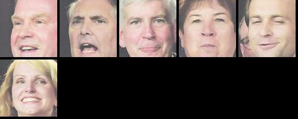

```
Results found in file a-3.png
```

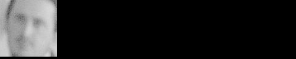

```python
# Generate output for the small file
for name in file_names:

    # take out all the meta-data related to the image
    image_dict = image_dictionary[name]
    generateOutput(image_dict, 'Christopher')
```

```python
# For the larger file
# Create a ZipFile object out of the images.zip file
zip_file_large = zipfile.ZipFile('readonly/images.zip')

# Get the names of the files inside the zipped file
file_names_large = zip_file_large.namelist()

# Create a dictionary to store information about each image so that it can later we can loop through the images
image_dictionary_large = {}
for name in file_names_large:

    image_object_large = Image.open(zip_file_large.open(name))
    image_dictionary_large[name] = {'name':     name,
                                    'image':    image_object_large,
                                    'size':     image_object_large.size,
                                    'mode':     image_object_large.mode,
                                    'text':     pt.image_to_string(image_object_large)}

    # print('finished processing {}'.format(name))
```

[output not shown]

```
Results found in file a-0.png
```

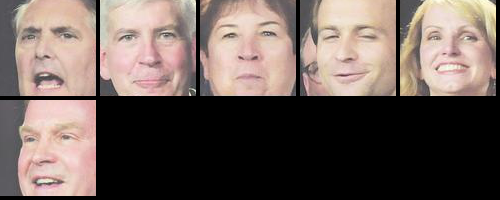

```
Results found in file a-1.png
```

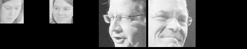

```
Results found in file a-10.png
But there were no faces in that file!
Results found in file a-13.png
```

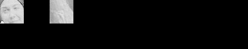

```
Results found in file a-2.png
```

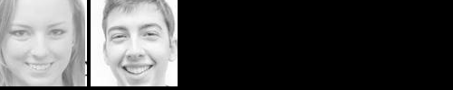

```
Results found in file a-3.png
```

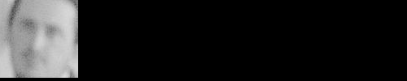

```
Results found in file a-8.png
But there were no faces in that file!
```

```python
# Generate output for the larger file, but search for 'Mark' this time
for name in file_names_large:

    # take out all the meta-data related to the image
    image_dict = image_dictionary_large[name]
    generateOutput(image_dict, 'Mark')
```